# Taller 1 Procesos Estocasticos

Miguel Angel Garcia Osorio y Dorian Alejandro Guisao Ospina

# Problema 1: Simulación MCMC y verificación de la distribución estacionaria

Tenemos la siguiente cadena de Markov

$$x_t = \beta x_{t-1} + \varepsilon_t,
\quad \varepsilon_t \overset{iid}{\sim} N(0,1), \quad \beta =
0.1$$

y la siguiente distribución estacionaria teórica:

$$X_t \sim N\left(0,\,
\frac{1}{1-\beta^2}\right) = N(0,\, 1.0101)$$

El objetivo es verificar empíricamente, mediante métodos gráficos y tests formales, que la simulación efectivamente converge a esta distribución.

## Parámetros y simulación

```r
beta    <- 0.1
n       <- 20000
burn_in <- 2000
```

```r
x <- numeric(n)
epsilon <- rnorm(n, mean = 0, sd = 1)
for (t in 2:n) {
  x[t] <- beta * x[t-1] + epsilon[t]
}

# Eliminamos el período de burn-in
x_stationary <- x[(burn_in + 1):n]
```

Los valores teóricos de media y varianza de la distribución estacionaria son:

```r
mean_teorica <- 0
var_teorica  <- 1 / (1 - beta^2)
sd_teorica   <- sqrt(var_teorica)

cat("Media teorica:   ", mean_teorica)
```

```
## Media teorica:    0
```

```r
cat("\nVarianza teorica:", var_teorica)
```

```
##
## Varianza teorica: 1.010101
```

## 1. Convergencia de la cadena

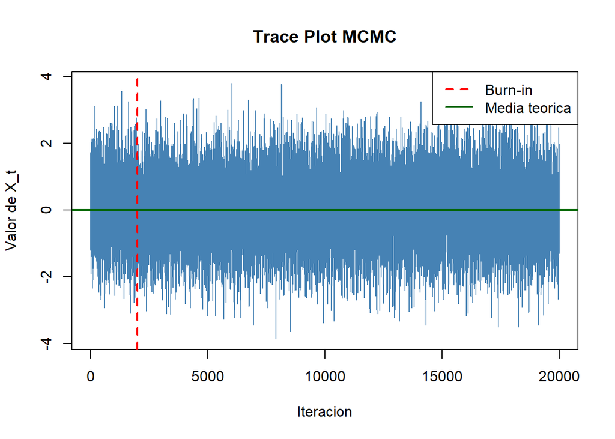

```r
plot(x, type = "l", col = "steelblue",
     main = "Trace Plot MCMC",
     xlab = "Iteracion", ylab = "Valor de X_t")
abline(v = burn_in,      col = "red",       lwd = 2, lty = 2)
abline(h = mean_teorica, col = "darkgreen", lwd = 2)
legend("topright", legend = c("Burn-in", "Media teorica"),
       col = c("red", "darkgreen"), lty = c(2, 1), lwd = 2)
```

El trace plot muestra que la cadena **mezcla rápidamente** y oscila de forma estable alrededor de la media teórica $\mu = 0$ desde las primeras iteraciones. Esto es consecuencia directa de que $\beta = 0.1$ es pequeño, lo que implica una autocorrelación muy débil entre iteraciones consecutivas. En otras palabras, la cadena olvida casi de inmediato su estado anterior. Este comportamiento es la primera señal de que la cadena ha alcanzado su distribución estacionaria.

## 2. Estadísticos muestrales vs teóricos

```r
cat("Media muestral:   ", mean(x_stationary))
```

```
## Media muestral:    -0.01071159
```

```r
cat("\nVarianza muestral:", var(x_stationary))
```

```
##
## Varianza muestral: 1.009732
```

| Cantidad | Valor teórico | Valor muestral |
| --- | --- | --- |
| Media | 0 | −0.0107 |
| Varianza | 1.0101 | 1.0097 |

Los valores muestrales de media y varianza son muy cercanos a los teóricos, lo cual es un primer indicio — aunque no una prueba definitiva — de que la cadena podría estar convergiendo a la distribución $N(0, 1.0101)$ La pequeña diferencia observada en la media y varianza es esperable dado el tamaño de la muestra, y no genera preocupación. Para confirmar esta hipótesis, recurrimos a métodos gráficos y tests formales en las secciones siguientes.

## 3. Histograma vs densidad teórica

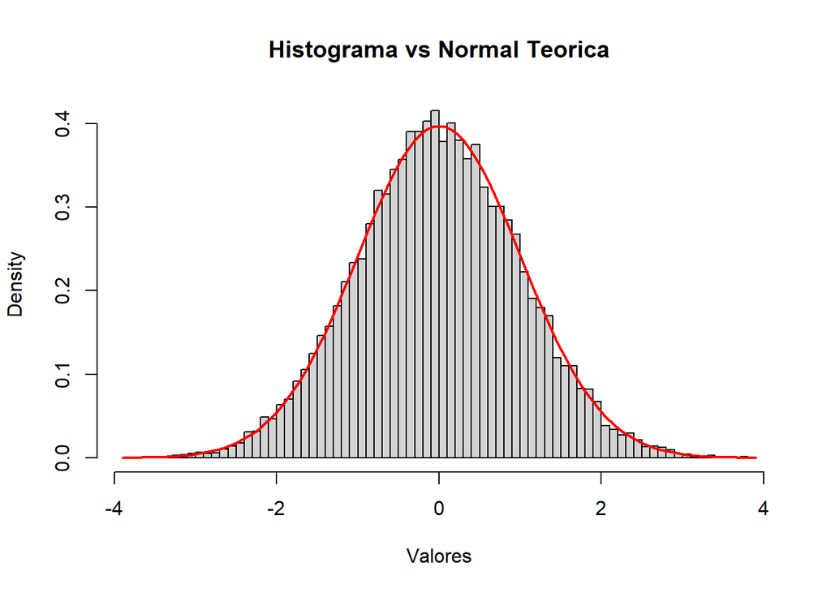

```r
hist(x_stationary, probability = TRUE, breaks = 65,
     main = "Histograma vs Normal Teorica",
     xlab = "Valores")
curve(dnorm(x, mean = mean_teorica, sd = sd_teorica),
      col = "red", lwd = 2, add = TRUE)
```

El histograma de los valores post burn-in se ajusta visualmente de forma muy precisa a la curva de densidad $N(0,\, 1.0101)$ (línea roja). La distribución empírica es simétrica, unimodal y centrada en cero, sin indicios de asimetría ni colas pesadas. Esto constituye una primera confirmación gráfica de que la distribución estacionaria es la normal teórica.

## 4. QQ-Plot

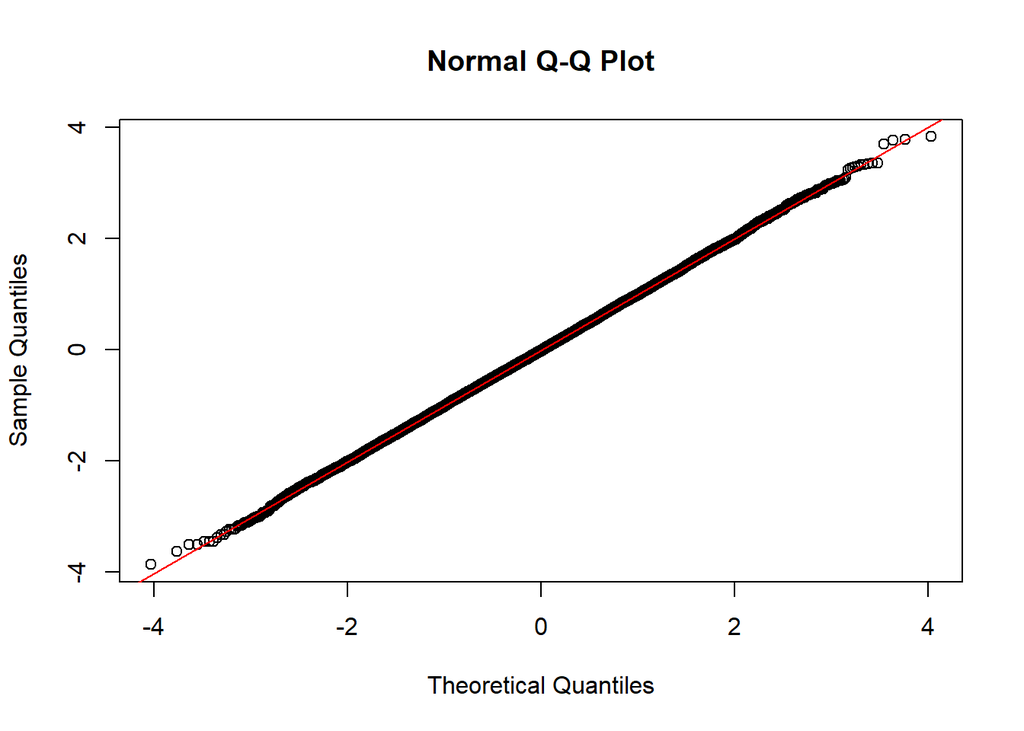

```r
qqnorm(x_stationary, main = "Normal Q-Q Plot")
qqline(x_stationary, col = "red")
```

El QQ-plot compara los cuantiles empíricos de la muestra contra los cuantiles teóricos de una distribución normal. Los puntos siguen la línea de referencia con gran precisión a lo largo de **todo el rango**, incluyendo las colas. Las leves desviaciones en los extremos ($\pm 4$) son esperables en muestras grandes y no comprometen la conclusión. Este gráfico refuerza que la distribución estacionaria es normal.

## 5. Tests formales de normalidad

### Shapiro-Wilk

```r
shapiro.test(sample(x_stationary, 5000))
```

```
##
##  Shapiro-Wilk normality test
##
## data:  sample(x_stationary, 5000)
## W = 0.99974, p-value = 0.81
```

El test de Shapiro-Wilk se aplica sobre una submuestra de 5000 observaciones (límite del test). El estadístico $W = 0.99974$ es extremadamente cercano a 1, y el p-value $= 0.81$ es muy superior al nivel de significancia usual de $0.05$. Por lo tanto, **no se rechaza $H_0$** de normalidad. No hay evidencia estadística para descartar que los datos provengan de una distribución normal.

### Kolmogorov-Smirnov

```r
ks.test(x_stationary, "pnorm",
        mean = mean_teorica,
        sd   = sd_teorica)
```

```
##
##  Asymptotic one-sample Kolmogorov-Smirnov test
##
## data:  x_stationary
## D = 0.0083076, p-value = 0.1666
## alternative hypothesis: two-sided
```

El test de Kolmogorov-Smirnov compara la función de distribución empírica directamente contra la $N(0,\, 1.0101)$ teórica, usando la muestra completa de 18000 observaciones post burn in. El estadístico $D = 0.0083$ refleja una distancia mínima entre ambas distribuciones, y el p-value $= 0.167$ no permite rechazar $H_0$. Esto confirma que **la distribución empírica es consistente con la $N(0,\, 1.0101)$ teórica**.

## Conclusión

El conjunto de evidencias presentadas. Convergencia del trace plot, concordancia de momentos, ajuste del histograma, linealidad del QQ-plot y resultados de los tests formales apunta de forma consistente a la conclusión esperada: la distribución estacionaria de la cadena $x_t = 0.1\, x_{t-1} + \varepsilon_t$ es efectivamente

$$N\!\left(0,\, \frac{1}{1-\beta^2}\right)
= N(0,\, 1.0101)$$

# Problema 2: Simulación de una Beta(2,6) via Metropolis-Hastings

En este problema la densidad objetivo es una $\text{Beta}(2, 6)$:

$$f(x) =
\frac{x^{\alpha-1}(1-x)^{\beta-1}}{B(\alpha,\beta)}, \quad x \in (0,1),
\quad \alpha=2,\ \beta=6$$

### Implementación

```r
set.seed(123)
n          <- 30000
burn_in    <- 3000
sigma_prop <- 0.22

f <- function(x) dbeta(x, 2, 6)
```

Se utiliza una caminata aleatoria normal como distribución propuesta: $Y_t \sim N(x_t,\ \sigma^2_{prop})$ con $\sigma_{prop} = 0.22$. La elección de esta propuesta responde a dos criterios. Primero, el algoritmo de Metropolis-Hastings requiere asociar a la densidad objetivo $f$ una densidad propuesta $q(\cdot | y)$ que sea fácil de simular y cuyo soporte contenga al soporte de $f$; la normal cumple ambas condiciones, ya que es trivial simular de ella y su soporte es $\mathbb{R}$, el cual contiene al soporte $(0,1)$ de la $\text{Beta}(2,6)$. Segundo, la caminata aleatoria normal es una de las propuestas más utilizadas en implementaciones prácticas de MH, lo que la convierte en una elección sencilla como punto de partida.

```r
# Inicialización
x <- numeric(n)
x[1] <- 0.5   # Punto de inicio
accept <- 0


# Algoritmo Metropolis-Hastings
for (t in 1:(n-1)) {

  # Caminata aleatoria normal
  y <- rnorm(1, mean = x[t], sd = sigma_prop)

  # Verificación de soporte y razón de aceptación
  prob_y <- f(y)
  prob_x <- f(x[t])

  if (prob_y > 0) {
    rho <- min(prob_y / prob_x, 1)

    if (runif(1) < rho) {
      x[t+1] <- y
      accept <- accept + 1
    } else {
      x[t+1] <- x[t]
    }
  } else {
    # Fuera de soporte: Rechazo automático
    x[t+1] <- x[t]
  }
}

# Tasa de aceptación

tasa_aceptacion <- accept / n
cat("Tasa de aceptacion final:", round(tasa_aceptacion, 3), "\n")
```

```
## Tasa de aceptacion final: 0.575
```

La tasa de aceptación obtenida es de 57.5%. Esto indica que $\sigma_{prop}$ podría aumentarse ligeramente para proponer saltos más ambiciosos, aunque como veremos, los métodos gráficos y test confirman que los resultados son válidos.

### Post-procesamiento: Burn-in y Thinning

```r
x_after_burn <- x[(burn_in + 1):n]
x_mcmc       <- x_after_burn[seq(1, length(x_after_burn), by = 20)]
```

Se eliminan las primeras 3000 iteraciones como período de burn-in. Adicionalmente, se aplica **thinning**, reteniendo 1 de cada 20 muestras. Esta decisión responde a dos motivos relacionados.

El primero es la autocorrelación: en MH con caminata aleatoria, cuando el algoritmo rechaza un salto propuesto, el valor anterior se repite exactamente. Esto genera dependencia entre iteraciones consecutivas que puede sesgar los diagnósticos. El segundo motivo es más técnico: esa repetición exacta de valores produce **empates** (Se producen aquí: `# Fuera de soporte: Rechazo automático x[t+1] <- x[t]`) en la muestra, lo cual es problemático para el test de Kolmogorov-Smirnov, que asume variables continuas donde la probabilidad de observar dos valores idénticos es cero. La presencia de empates genera escalones artificiales en la función de distribución empírica e invalida el cálculo estándar del estadístico $D$. El thinning resuelve ambos problemas simultáneamente.

### 1. Convergencia

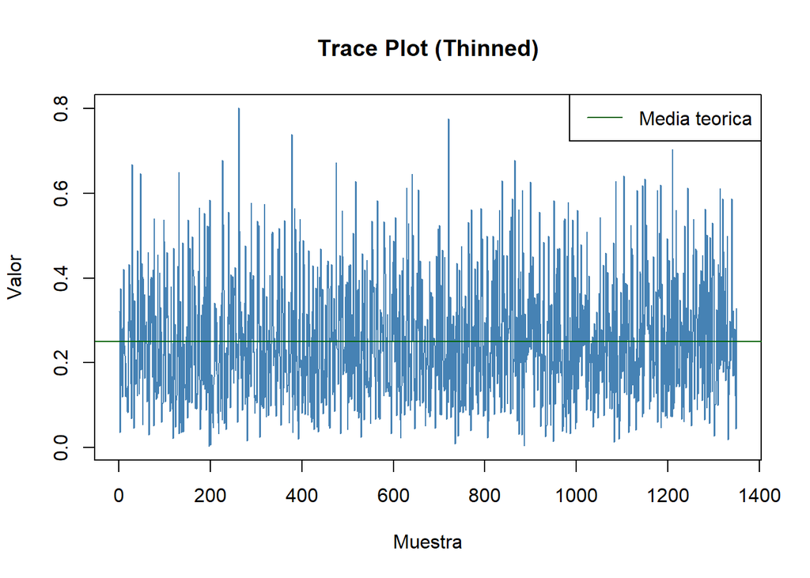

```r
plot(x_mcmc, type = "l", col = "steelblue",
     main = "Trace Plot (Thinned)", xlab = "Muestra", ylab = "Valor")
abline(h = 2/(2+6), col = "darkgreen", lty = 1)
legend("topright", legend = "Media teorica", col = "darkgreen", lty = 1)
```

La cadena mezcla bien y oscila establemente alrededor de la media teórica $\mu = 0.25$ (línea verde) a lo largo de todas las muestras post burn-in. No se observan períodos de estancamiento ni tendencias sistemáticas, lo que es un primer indicio de que la cadena ha alcanzado su distribución estacionaria.

### 2. Autocorrelación

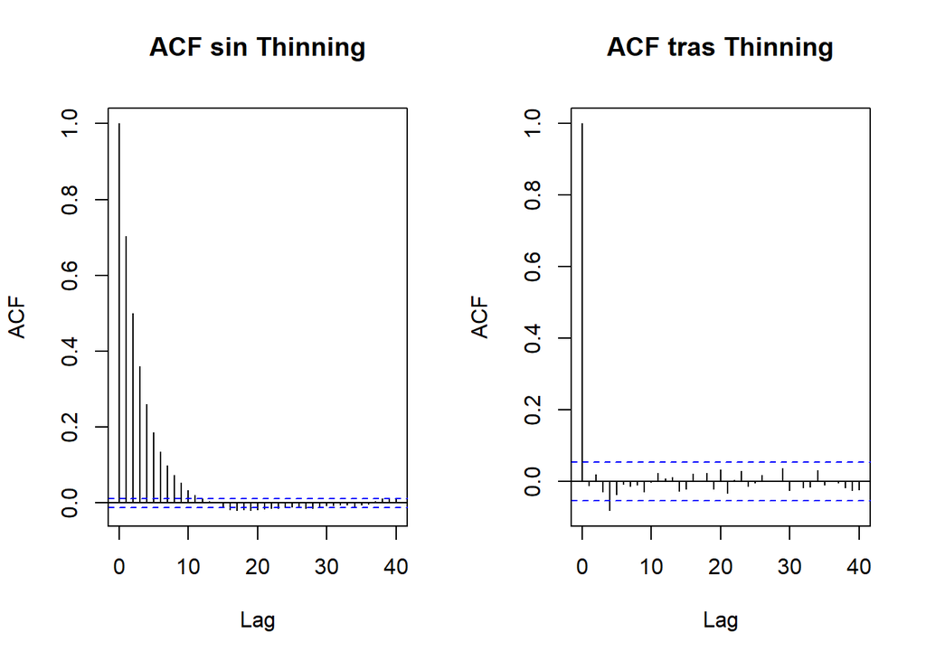

```r
par(mfrow = c(1, 2))

acf(x_after_burn, main = "ACF sin Thinning", lag.max = 40)
acf(x_mcmc,       main = "ACF tras Thinning", lag.max = 40)
```

```r
par(mfrow = c(1, 1))
```

### 3. Histograma vs densidad teórica

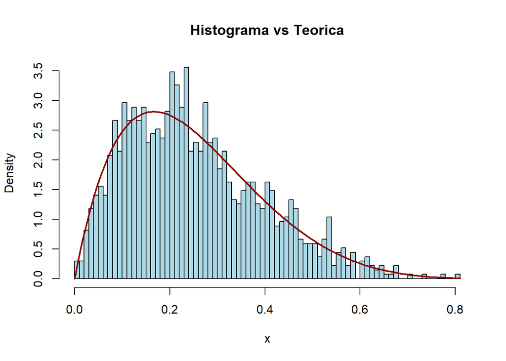

```r
hist(x_mcmc, probability = TRUE, breaks = 65, col = "lightblue",
     main = "Histograma vs Teorica", xlab = "x")
curve(dbeta(x, 2, 6), col = "darkred", lwd = 2, add = TRUE)
```

El histograma reproduce la forma característica de la $\text{Beta}(2,6)$: asimétrica a la derecha, con moda cerca de $x = 0.2$ y cola larga hacia valores altos. El ajuste a la curva teórica es visualmente bueno, lo que constituye un indicio de que la simulación está capturando correctamente la distribución objetivo.

### 4. QQ-Plot vs Beta(2,6)

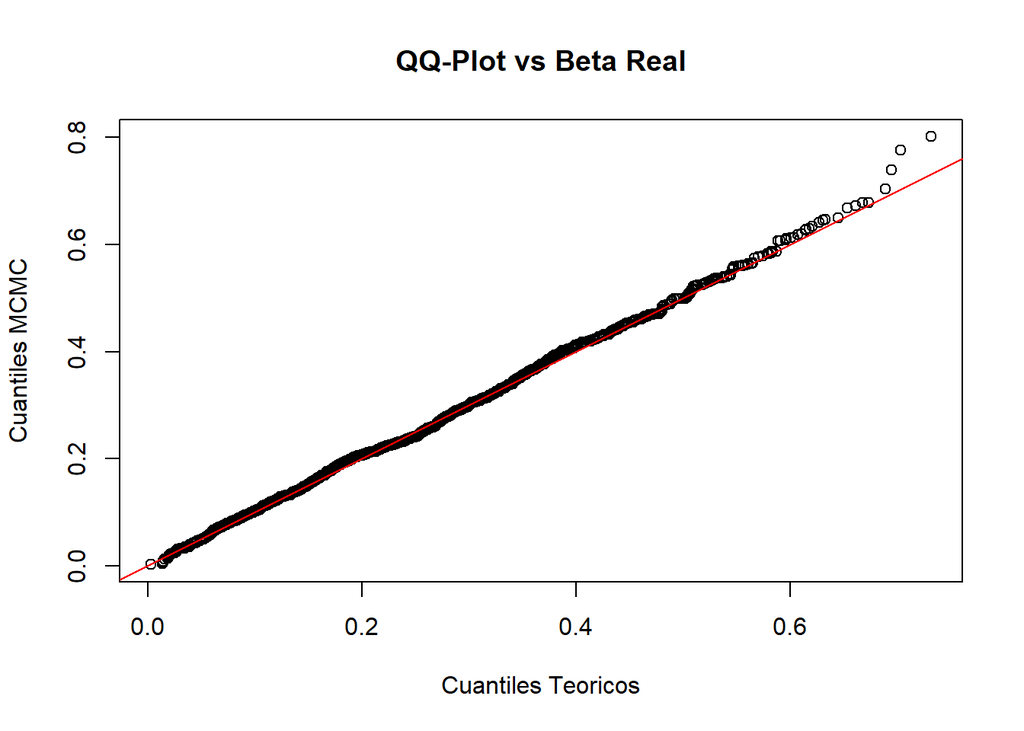

```r
qqplot(rbeta(length(x_mcmc), 2, 6), x_mcmc,
       main = "QQ-Plot vs Beta Real",
       xlab = "Cuantiles Teoricos", ylab = "Cuantiles MCMC")
abline(0, 1, col = "red")
```

A diferencia del Problema 1, aquí el QQ-plot no compara contra una normal sino directamente contra cuantiles simulados de una $\text{Beta}(2,6)$, que es la comparación correcta para este caso en específico. Los puntos siguen la línea de referencia con buena precisión en la mayor parte del rango. Las pequeñas desviaciones en la cola superior ($x > 0.6$) son esperables dada la escasez de observaciones en esa región, y no representan una desviación sistemática preocupante, aunque si es indica que la exploración en esa zona es baja o que el algoritmo subestima la probabilidad en esa zona.

### 5. Test de Kolmogorov-Smirnov

```r
ks_test <- ks.test(x_mcmc, "pbeta", 2, 6)
print(ks_test)
```

```
##
##  Asymptotic one-sample Kolmogorov-Smirnov test
##
## data:  x_mcmc
## D = 0.021799, p-value = 0.5426
## alternative hypothesis: two-sided
```

El test reporta $D = 0.0218$ y $\text{p-value} = 0.5426$. La distancia máxima entre la distribución empírica y la $\text{Beta}(2,6)$ teórica es muy pequeña, y el p-value es ampliamente superior al nivel de significancia usual de $0.05$. **No se rechaza $H_0$**, lo que indica que los datos simulados son estadísticamente consistentes con la distribución objetivo.

### Conclusión

El conjunto de diagnósticos aplicados apunta de forma consistente a la misma conclusión: el algoritmo de Metropolis-Hastings implementado simula correctamente variables aleatorias de una $\text{Beta}(2, 6)$. El trace plot confirma estacionariedad, la comparación de ACF confirma que el thinning eliminó la autocorrelación, el histograma y QQ-plot muestran buen ajuste a la forma teórica, y el test KS formaliza que no existe diferencia estadísticamente significativa entre la muestra MCMC y la distribución objetivo.

# Problema 3: Metropolis Hastling

## Muestra aleatoria

Se genera una muestra aleatoria de tamaño 100 proveniente de la distribución mezclada

$$f(y \mid \alpha)
=
(1-\alpha)\, f_{\mathcal{N}(8,5)}(y)
+
\alpha\, f_{t_{3}(10)}(y)$$

La simulación se realiza generando primero una muestra Bernoulli con probabilidad de éxito $\alpha = 0.7$.  
Para cada observación:

- Si el resultado es 1, se genera un valor de una distribución $t$ con $\nu = 3$ centrada en 10.
- Si el resultado es 0, se genera un valor de una distribución Normal con media 8 y desviación estándar 5.

```r
alpha <- 0.7
lista_binom <- rbinom(100,1,alpha)

MA <- numeric(100)
i <- 1
for (ensayo in lista_binom){
  if(ensayo == 1){
    MA[i] <- 10 + rt(1,df = 3)
  }else{
        MA[i] <- rnorm(1,mean = 8, sd = 5)
  }
  i<- i+1
}



print(MA)
```

```
##   [1] 11.907679 10.087159  6.240310 10.918056  4.470868 10.338435  4.127111
##   [8]  8.697947  8.219186  9.922798 11.085801  8.442116  8.847543  2.295435
##  [15] 11.350004 10.641652 15.024202  8.980940  8.947254 10.006133 11.384389
##  [22]  5.400052  3.626065  5.924646  8.798423 12.432046  9.552639  9.490581
##  [29]  9.222726 12.458160 10.452904  9.444883  9.503765 13.492706 10.372738
##  [36] 11.870360 10.563208 10.640162  9.761570 10.377025  3.983647 10.827186
##  [43]  7.923648  9.507048  8.307221 10.726755  9.047658 12.115688 11.042731
##  [50]  8.913501  9.898192  8.845717  9.231212 10.560364  9.517922  9.280888
##  [57]  8.372682 11.236156  9.510389 10.236575  8.860031 16.995353 11.318090
##  [64] 18.141543  5.079058  7.238838 10.474970 12.819643  9.435350 11.249183
##  [71]  6.592500  9.575049  8.712578  9.758790  8.545961 10.676265  6.407369
##  [78] 12.057432 10.169850  8.362813 11.105166  7.726511 10.536812 10.564924
##  [85]  9.561814  8.990813  8.963063  8.241658  1.845247  3.914400 13.640114
##  [92] -1.225824 11.597151  9.119280 10.502052  8.065485 11.685548  9.200441
##  [99] 13.309083 10.395783
```

## Calculo de funcion de verosimilitud

Calculamos $p(y|\alpha)$ usando los datos ya simulados

```r
verosimilitud <- function(alpha, y){

  densidades <- (1 - alpha) * dnorm(y, mean = 8, sd = 5) +
                 alpha * dt(y - 10, df = 3)

  prod(densidades)
}
```

# Algoritmo Metropolis–Hastings

Tenemos la verosimilitud $p(y \mid \alpha)$, pero nuestro interés es estimar la distribución posterior $p(\alpha \mid y)$, ya que esta describe la proporción de observaciones provenientes de la distribución t-Student ($\nu=3$) frente a la Normal$(8,5)$.

Aplicando el Teorema de Bayes:

$$p(\alpha \mid y)
=
\frac{p(\alpha)\,p(y \mid \alpha)}{p(y)},$$

y como $p(y)$ no depende de $\alpha$, obtenemos

$$p(\alpha \mid y)
\propto
p(\alpha)\,p(y \mid \alpha)
= p(\alpha)\,L(\alpha),$$

donde $p(\alpha)$ es la distribución a priori y $L(\alpha)$ es la verosimilitud.

Dado que esta distribución posterior no tiene forma cerrada, utilizamos el algoritmo **Metropolis–Hastings**, el cual construye una cadena de Markov cuya distribución estacionaria es $p(\alpha \mid y)$.

En cada iteración se propone un nuevo valor $\alpha^*$ y se acepta con probabilidad

$$\rho
=
\min\left(
\frac{p(\alpha^*) L(\alpha^*)}
{p(\alpha^{(t)}) L(\alpha^{(t)})},
1
\right).$$

De esta manera se generan muestras aproximadas de la distribución posterior, permitiendo estimar cantidades como

$$E(\alpha \mid y).$$

- Creamos la funcion prior y posterior

```r
prior <- function(alpha, a, b){
  dbeta(alpha, a, b)
}

posterior <- function(alpha, y, a, b){

  if(alpha <= 0 || alpha >= 1) return(0) # debido a que 0<=alpha<=1

  prior(alpha, a, b) * verosimilitud(alpha, y)
}
```

- Inicializamos la MCMC con 10.000 iteraciones, un $\alpha_0$ = 0.5 y $\sigma$ = 0.05

```r
n_iter <- 10000
alpha_chain <- numeric(n_iter)
alpha_chain[1] <- 0.5
sigma_prop <- 0.05
y <- MA

a1 <- 1
b1 <- 1

a2 <- 2
b2 <- 10
```

- Implementación de Metropolis–Hastings para beta(1,1)

```r
for(t in 2:n_iter){

  alpha_current <- alpha_chain[t-1]
  alpha_proposed <- rnorm(1, alpha_current, sigma_prop)

  p <- posterior(alpha_proposed, y, a1, b1) /
       posterior(alpha_current, y, a1, b1)

  p <- min(p, 1)

  if(runif(1) < p){
    alpha_chain[t] <- alpha_proposed
  } else {
    alpha_chain[t] <- alpha_current
  }
}
```

Calculamos
$$E(\alpha \mid y). para beta(1,1)$$
, primero eliminando el “burn in”, osea datos que usamos inicialmente que probablemente no sigan la misma distribucion que estamos buscando y luego sacamos la esperanza a lo que nos queda.

```r
burn_in <- 2000
posterior_samples <- alpha_chain[(burn_in+1):n_iter]

mean(posterior_samples)
```

```
## [1] 0.7194747
```

- Ahora lo calculamos pero con un prior beta(2,10)

```r
for(t in 2:n_iter){

  alpha_current <- alpha_chain[t-1]
  alpha_proposed <- rnorm(1, alpha_current, sigma_prop)

  p <- posterior(alpha_proposed, y, a2, b2) /
       posterior(alpha_current, y, a2, b2)

  p <- min(p, 1)

  if(runif(1) < p){
    alpha_chain[t] <- alpha_proposed
  } else {
    alpha_chain[t] <- alpha_current
  }
}

burn_in <- 2000
posterior_samples <- alpha_chain[(burn_in+1):n_iter]

mean(posterior_samples)
```

```
## [1] 0.5932104
```